# DATA 607 Assignment 2

Susanna Wong

2023-02-04

# Introduction

# Storing Data in My SQL

```
-- MySQL Script generated by MySQL Workbench
-- Sun Feb 12 23:51:29 2023
-- Model: New Model    Version: 1.0
-- MySQL Workbench Forward Engineering

SET @OLD_UNIQUE_CHECKS=@@UNIQUE_CHECKS, UNIQUE_CHECKS=0;
SET @OLD_FOREIGN_KEY_CHECKS=@@FOREIGN_KEY_CHECKS, FOREIGN_KEY_CHECKS=0;
SET @OLD_SQL_MODE=@@SQL_MODE, SQL_MODE='ONLY_FULL_GROUP_BY,STRICT_TRANS_TABLES,NO_ZERO_IN_DATE,NO_ZERO_DATE,ERROR_FOR_DIVISION_BY_ZERO,NO_ENGINE_SUBSTITUTION';

-- -----------------------------------------------------
-- Schema mydb
-- -----------------------------------------------------
SHOW WARNINGS;
-- -----------------------------------------------------
-- Schema Movie Rating
-- -----------------------------------------------------
DROP SCHEMA IF EXISTS `Movie Rating` ;

-- -----------------------------------------------------
-- Schema Movie Rating
-- -----------------------------------------------------
CREATE SCHEMA IF NOT EXISTS `Movie Rating` DEFAULT CHARACTER SET utf8mb4 COLLATE utf8mb4_0900_ai_ci ;
SHOW WARNINGS;
USE `Movie Rating` ;

-- -----------------------------------------------------
-- Table `Movie`
-- -----------------------------------------------------
DROP TABLE IF EXISTS `Movie` ;

SHOW WARNINGS;
CREATE TABLE IF NOT EXISTS `Movie` (
  `id Movie` INT NOT NULL,
  `Movie Name` VARCHAR(200) NOT NULL,
  `Genre` VARCHAR(45) NOT NULL,
  `Year` INT NOT NULL,
  PRIMARY KEY (`id Movie`))
ENGINE = InnoDB
DEFAULT CHARACTER SET = utf8mb4
COLLATE = utf8mb4_0900_ai_ci;
```

[output cut: 33 more lines]

```
CREATE TABLE IF NOT EXISTS `Person` (
  `idPerson` INT NOT NULL,
  `First Name` VARCHAR(45) NOT NULL,
  `Gender` VARCHAR(45) NOT NULL,
  `Age` VARCHAR(45) NOT NULL,
  PRIMARY KEY (`idPerson`))
ENGINE = InnoDB
DEFAULT CHARACTER SET = utf8mb4
COLLATE = utf8mb4_0900_ai_ci;

SHOW WARNINGS;

SET SQL_MODE=@OLD_SQL_MODE;
SET FOREIGN_KEY_CHECKS=@OLD_FOREIGN_KEY_CHECKS;
SET UNIQUE_CHECKS=@OLD_UNIQUE_CHECKS;
```

# Connect to SQL

```r
library(tidyverse)
library(DT)
library(RMySQL)
library(DBI)
dbconnect = dbConnect(RMySQL::MySQL(),
                           dbname='Movie Rating',
                           host='localhost',
                           port=3306,
                           user='root',
                           password = rstudioapi::askForPassword("Database password"))

rating <- dbGetQuery(dbconnect, "SELECT * FROM `Movie Rating`.`Movie Rating`")
datatable(rating)
```

|  | idRating | Name | Gender | Age | Avengers: Endgame | Everything Everywhere All at Once | Black Panther: Wakanda Forever | Scream | Doctor Strange in the Multiverse of Madness | Top Gun: Maverick |
| --- | --- | --- | --- | --- | --- | --- | --- | --- | --- | --- |
| 1 | 1 | Mel | Female | 23 | 5 |  | 3 | 3 | 4 | 3 |
| 2 | 2 | Jenny | Female | 29 | 5 | 4 | 4 |  | 4 | 5 |
| 3 | 3 | James | Male | 37 | 5 | 4 | 4 |  | 4 | 4 |
| 4 | 4 | Ivan | Male | 28 | 4 |  | 3 |  | 5 | 4 |
| 5 | 5 | Helen | Female | 24 | 5 | 4 | 3 | 3 | 4 | 3 |
| 6 | 6 | Jack | Male | 15 | 5 |  | 3 |  | 3 |  |
| 7 | 7 | Bob | Male | 45 | 4 |  | 4 | 2 | 4 | 2 |
| 8 | 8 | Emma | Female | 21 | 4 | 3 | 3 | 3 | 4 | 4 |

# Movie

Below is a table of the movies that each person is rating.

```r
movies <- dbGetQuery(dbconnect, "SELECT * FROM `Movie Rating`.Movie;")
datatable(movies, caption = 'Table 1: Movie title and Year')
```

|  | id Movie | Movie Name | Genre | Year |
| --- | --- | --- | --- | --- |
| 1 | 1 | Avengers: Endgame | action | 2019 |
| 2 | 2 | Everything Everywhere All at Once | comedy | 2022 |
| 3 | 3 | Black Panther: Wakanda Forever | action | 2022 |
| 4 | 4 | Scream | horror | 2022 |
| 5 | 5 | Doctor Strange in the Multiverse of Madness | adventure | 2022 |
| 6 | 6 | Top Gun: Maverick | action | 2022 |

# Reviewer Information

Here is table of first name, age, and gender of each person.

```r
person <- dbGetQuery(dbconnect, "SELECT * FROM `Movie Rating`.Person;")
datatable(person, caption = 'Table 2: Information of Reviewers')
```

|  | idPerson | First Name | Gender | Age |
| --- | --- | --- | --- | --- |
| 1 | 1 | Mel | Female | 23 |
| 2 | 2 | Jenny | Female | 29 |
| 3 | 3 | James | Male | 37 |
| 4 | 4 | Ivan | Male | 28 |
| 5 | 5 | Helen | Female | 24 |
| 6 | 6 | Jack | Male | 15 |
| 7 | 7 | Bob | Male | 45 |
| 8 | 8 | Emma | Female | 21 |

# Analysis

```r
rating <- dbGetQuery(dbconnect, "SELECT * FROM `Movie Rating`.`Movie Rating`")
datatable(rating, caption = 'Table 3: Ratings of each movie.')
```

|  | idRating | Name | Gender | Age | Avengers: Endgame | Everything Everywhere All at Once | Black Panther: Wakanda Forever | Scream | Doctor Strange in the Multiverse of Madness | Top Gun: Maverick |
| --- | --- | --- | --- | --- | --- | --- | --- | --- | --- | --- |
| 1 | 1 | Mel | Female | 23 | 5 |  | 3 | 3 | 4 | 3 |
| 2 | 2 | Jenny | Female | 29 | 5 | 4 | 4 |  | 4 | 5 |
| 3 | 3 | James | Male | 37 | 5 | 4 | 4 |  | 4 | 4 |
| 4 | 4 | Ivan | Male | 28 | 4 |  | 3 |  | 5 | 4 |
| 5 | 5 | Helen | Female | 24 | 5 | 4 | 3 | 3 | 4 | 3 |
| 6 | 6 | Jack | Male | 15 | 5 |  | 3 |  | 3 |  |
| 7 | 7 | Bob | Male | 45 | 4 |  | 4 | 2 | 4 | 2 |
| 8 | 8 | Emma | Female | 21 | 4 | 3 | 3 | 3 | 4 | 4 |

Below is a table of the average rating of each movie. Some people did not see certain movies. So there are missing values. I used “na.rm = TRUE” to deal with missing values. Avengers: Endgame has the highest average rating and Scream has the lowest average rating. Both movies “Everything Everywhere All at Once” and “Scream” had 4 missing values each. Yet, “Everything Everywhere All at Once” had a higher average rating than “Scream” did.

```r
# #new <-rating%>%
#   summarise(Avengers= mean(rating[, 5],na.rm = TRUE),Everything.Everywhere.All.at.Once= mean(rating[, 6],na.rm = TRUE), Black.Panther= mean(rating[, 7],na.rm = TRUE), Scream = mean(rating[, 8],na.rm = TRUE), Doctor.Strange= mean(rating[, 9],na.rm = TRUE), Top.Gun= mean(rating[, 10],na.rm = TRUE))
#
# datatable(new, caption = 'Table 4: Average rating of each movie.')

Avengers= mean(rating[, 5],na.rm = TRUE)
Everything.Everywhere.All.at.Once= mean(rating[, 6],na.rm = TRUE)
Black.Panther= mean(rating[, 7],na.rm = TRUE)
Scream = mean(rating[, 8],na.rm = TRUE)
Doctor.Strange= mean(rating[, 9],na.rm = TRUE)
Top.Gun= mean(rating[, 10],na.rm = TRUE)
Movies <- c('Avengers: Endgame','Everything Everywhere All at Once','Black Panther: Wakanda Forever','Scream','Doctor Strange in the Multiverse of Madness','
Top Gun: Maverick' )
Average_Rating <- c(Avengers,Everything.Everywhere.All.at.Once, Black.Panther, Scream, Doctor.Strange,  Top.Gun)

new1 <- data.frame(Movies, Average_Rating)
datatable(new1, caption = 'Table 4: Average rating of each movie.')
```

|  | Movies | Average_Rating |
| --- | --- | --- |
| 1 | Avengers: Endgame | 4.625 |
| 2 | Everything Everywhere All at Once | 3.75 |
| 3 | Black Panther: Wakanda Forever | 3.375 |
| 4 | Scream | 2.75 |
| 5 | Doctor Strange in the Multiverse of Madness | 4 |
| 6 | Top Gun: Maverick | 3.57142857142857 |

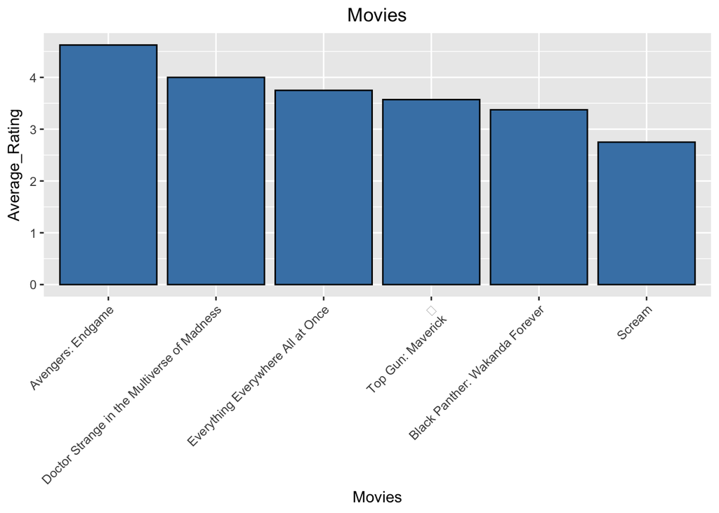

```r
p <- ggplot(new1, aes(x=reorder(Movies,-Average_Rating), y= Average_Rating)) + ggtitle("Movies") + theme(plot.title=element_text(hjust=0.5))+theme(axis.text.x=element_text(angle=45,hjust=1))+ xlab("Movies")+ ylab("Average_Rating")+
geom_bar(stat = "identity",fill = "steelblue", color = "black")
p + scale_y_continuous(labels = function(x) format(x, scientific = FALSE))
```

# Do either gender have a movie preference?

The following movies has a higher average rating from females : ‘Avengers: Endgame’, ‘Scream’, and ‘Top Gun: Maverick’.

The following movies has a higher average rating from males : ‘Everything Everywhere All at Once’, and ‘Black Panther: Wakanda Forever’.

```r
names(rating) <- c('id', 'Name', 'Gender', 'Age', 'Avengers', 'Everything.Everywhere.All.at.Once', 'Black.Panther', 'Scream', 'Doctor.Strange', 'Top.Gun')
new2 <-rating%>%
  group_by(Gender)%>%
  summarise(Avengers=mean(Avengers, na.rm = TRUE), Everything.Everywhere.All.at.Once=mean(Everything.Everywhere.All.at.Once, na.rm = TRUE), Black.Panther = mean(Black.Panther, na.rm = TRUE), Scream = mean(Scream, na.rm = TRUE), Doctor.Strange=mean(Doctor.Strange, na.rm = TRUE), Top.Gun = mean(Top.Gun,na.rm = TRUE))

datatable(new2)
```

|  | Gender | Avengers | Everything.Everywhere.All.at.Once | Black.Panther | Scream | Doctor.Strange | Top.Gun |
| --- | --- | --- | --- | --- | --- | --- | --- |
| 1 | Female | 4.75 | 3.66666666666667 | 3.25 | 3 | 4 | 3.75 |
| 2 | Male | 4.5 | 4 | 3.5 | 2 | 4 | 3.33333333333333 |